# Discord Message Visulization

```r
library(RiceMessageVisualization)
library(readxl)
```

```r
ProjectData <- read_excel("Final/RiceMessageVisualization/Data/FinalProjectData.xlsx",
    sheet = "MessageHistory")
```

## Discord Message Visualization Package

By default for all functions, `user_col = "Author"` and `time_col = "Timestamp_clean"`.

### Discord_TimeConvert()

Converts column from YYYY-DD-MMTHH:MM:SS.SSSSSSSSS format into a format more suitable for ggplot2 and time series plots. The original format is the default one used by discord, so it is critical to have a function to easily reformat this data.

```r
CleanTime <- Discord_TimeConvert(ProjectData)
```

### Discord_Record()

Allows user to select the time period to search for, and finds the record amount of messages sent for each user within that time period across the entire dataset. It then returns the results ranked with the highest record.

```r
Discord_Record(CleanTime, search_window = 12)
```

```
## # A tibble: 35 × 3
##    Username     MaxMessages  Rank
##    <chr>              <dbl> <int>
##  1 mel                    6     1
##  2 machine_girl           5     2
##  3 wfmercury              5     3
##  4 derpstick              4     4
##  5 bbaited9               4     5
##  6 evergreen333           4     6
##  7 kikoni                 3     7
##  8 jayolite               3     8
##  9 burgermunch            3     9
## 10 irisflower8            3    10
## # ℹ 25 more rows
```

### Discord_TopUsers

Identifies the users with the highest total messages sent and generates a bar chart, labeling the total for each user. The number of users can be controlled with *n*

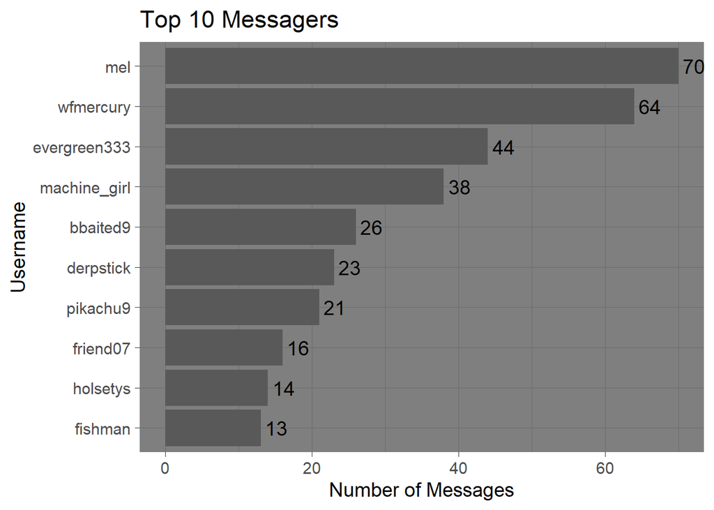

```r
Discord_TopUsers(CleanTime)
```

### Discord_TopDays

Generates time series showing the number of total messages sent for each day.

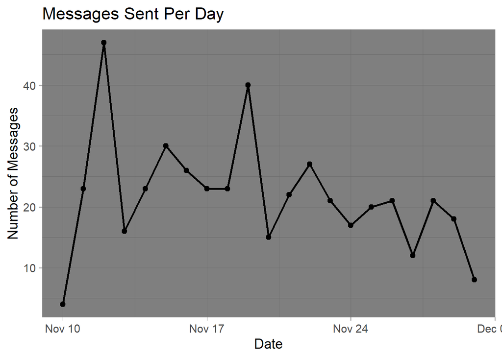

```r
Discord_TopDays(CleanTime, datetime_col = "Timestamp_clean")
```

### Discord_HeatMap

Generates a heat map showing the number of messages sent, organized by day of the week and hour. Can be used to identify which times and days have the most activity, and which time and days have the least activity.

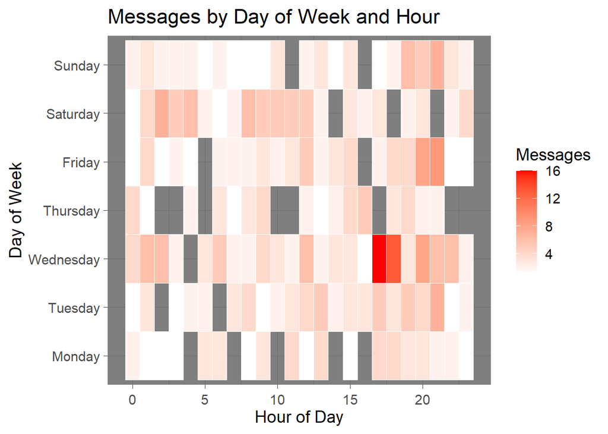

```r
Discord_HeatMap(CleanTime)
```

### Discord_TopUsersCumulative Identifies the most active users, and generates a time series plot showing how each user’s total messages accumulate over time. The number of users shown can be modified. n = 10 by default.

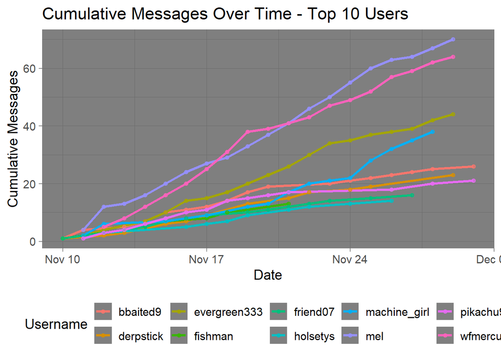

```r
Discord_TopUsersCumulative(CleanTime, datetime_col = "Timestamp_clean", user_col = "Author", top_n = 10, points = TRUE)
```

### Discord_HourDensity

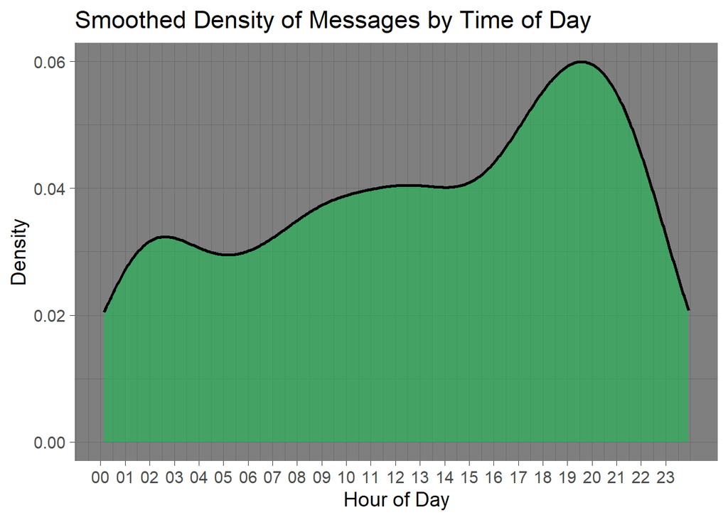

```r
Discord_HourDensity(CleanTime, datetime_col = "Timestamp_clean")
```

### Discord_TopUserActivity

Identifies the most active users, then creates a noncumulative time series documenting their daily activity. Number of users shown can be modified with *top_n*.

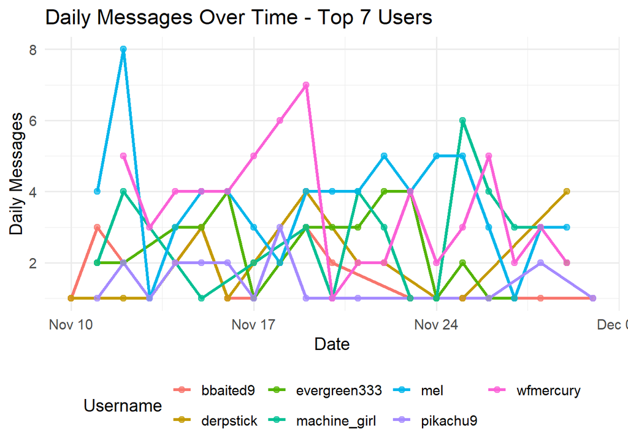

```r
Discord_TopUserActivity(CleanTime, top_n = 7)
```

### Discord_DailyTop

Identifies the top messager for each day and generates a bar chart showing how many messages that individual sent.

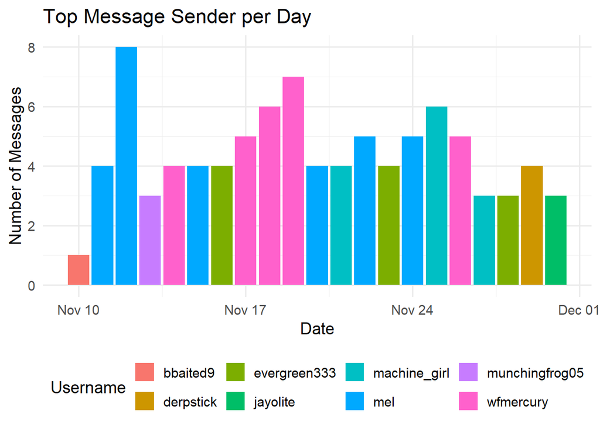

```r
Discord_DailyTop(CleanTime, datetime_col = "Timestamp_clean", user_col = "Author")
```